# Univariate analysis using NHANES data

This notebook will give you the opportunity to perform some univariate analyses on your own using the NHANES.

```python
%matplotlib inline
import matplotlib.pyplot as plt
import seaborn as sns
import pandas as pd
import statsmodels.api as sm
import numpy as np

da = pd.read_csv("nhanes_2015_2016.csv")
```

## Question 1

Relabel the marital status variable DMDMARTL to have brief but informative character labels. Then construct a frequency table of these values for all people, then for women only, and for men only. Then construct these three frequency tables using only people whose age is between 30 and 40.

```python
#Create an alternate dataframe so main data is unaltered
da_clean = da

#This is in order to relabel the numeric data to characters
da_clean['DMDMarrital'] = da.DMDMARTL.replace({1: 'Married', 2: 'Single', 3: 'In a Relationship', 4: 'Divorced',
                                         5: 'Complicated', 6: 'Not Interested', 77: 'Prefer not to say'})

#This code was in order to see the count in each strata
da_clean.DMDMarrital.value_counts()
```

```
Married              2780
Complicated          1004
In a Relationship     579
Not Interested        527
Single                396
Divorced              186
Prefer not to say       2
Name: DMDMarrital, dtype: int64
```

```python
#This was to be able to relabel the numeric data according to sex
da_clean['gender'] = da.RIAGENDR.replace({1: 'Male', 2: 'Female'})

#This was to see the count in each strata by gender
da_clean.groupby('gender')['DMDMarrital'].value_counts(normalize = True)
```

```
gender  DMDMarrital
Female  Married              0.457193
        Complicated          0.182456
        In a Relationship    0.122807
        Single               0.103860
        Not Interested       0.091930
        Divorced             0.041404
        Prefer not to say    0.000351
Male    Married              0.562881
        Complicated          0.184451
        Not Interested       0.100991
        In a Relationship    0.087271
        Single               0.038110
        Divorced             0.025915
        Prefer not to say    0.000381
Name: DMDMarrital, dtype: float64
```

```python
# this is to get the agegroup 30 to 40
da_clean["agegrp"] = pd.cut(da.RIDAGEYR, [30, 40])

#This was to see the stratified age group's 30-40 and see reported marrital status
da_clean.groupby("agegrp")["DMDMarrital"].value_counts()
```

```
agegrp    DMDMarrital
(30, 40]  Married              516
          Complicated          186
          Not Interested       129
          In a Relationship     67
          Divorced              29
          Single                 4
          Prefer not to say      1
Name: DMDMarrital, dtype: int64
```

```python
# Combining the two variables we created as filters to report marrital status
da_clean.groupby(['gender', 'agegrp'])['DMDMarrital'].value_counts().unstack()
```

| gender | DMDMarrital agegrp | Complicated | Divorced | In a Relationship | Married | Not Interested | Prefer not to say | Single |
| --- | --- | --- | --- | --- | --- | --- | --- | --- |
| Female | (30, 40] | 97.0 | 17.0 | 43.0 | 258.0 | 57.0 | NaN | 2.0 |
| Male | (30, 40] | 89.0 | 12.0 | 24.0 | 258.0 | 72.0 | 1.0 | 2.0 |

```python
#Replaced NaN variables in Table to 0
x = da_clean.groupby(['gender', 'agegrp'])['DMDMarrital'].value_counts().unstack()
x = x.fillna(0)
x
```

| gender | DMDMarrital agegrp | Complicated | Divorced | In a Relationship | Married | Not Interested | Prefer not to say | Single |
| --- | --- | --- | --- | --- | --- | --- | --- | --- |
| Female | (30, 40] | 97.0 | 17.0 | 43.0 | 258.0 | 57.0 | 0.0 | 2.0 |
| Male | (30, 40] | 89.0 | 12.0 | 24.0 | 258.0 | 72.0 | 1.0 | 2.0 |

**Q1a.** Briefly comment on some of the differences that you observe between the distribution of marital status between women and men, for people of all ages.

```python
#Created a new age strata covering ages with 10 years minimum difference
da_clean['agestrata'] = pd.cut(da.RIDAGEYR, [10,20, 30, 40, 50, 60, 70, 80])

#Replaced NaN variables in Table to 0
y = da_clean.groupby(['gender', 'agestrata'])['DMDMarrital'].value_counts().unstack()
y = y.fillna(0)
y
```

| gender | DMDMarrital agestrata | Complicated | Divorced | In a Relationship | Married | Not Interested | Prefer not to say | Single |
| --- | --- | --- | --- | --- | --- | --- | --- | --- |
| Female | (10, 20] | 30.0 | 0.0 | 0.0 | 1.0 | 8.0 | 0.0 | 0.0 |
|  | (20, 30] | 229.0 | 11.0 | 11.0 | 157.0 | 106.0 | 0.0 | 0.0 |
|  | (30, 40] | 97.0 | 17.0 | 43.0 | 258.0 | 57.0 | 0.0 | 2.0 |
|  | (40, 50] | 63.0 | 33.0 | 69.0 | 288.0 | 37.0 | 0.0 | 12.0 |
|  | (50, 60] | 42.0 | 27.0 | 83.0 | 257.0 | 32.0 | 1.0 | 28.0 |
|  | (60, 70] | 38.0 | 22.0 | 85.0 | 212.0 | 19.0 | 0.0 | 65.0 |
|  | (70, 80] | 21.0 | 8.0 | 59.0 | 130.0 | 3.0 | 0.0 | 189.0 |
| Male | (10, 20] | 36.0 | 0.0 | 0.0 | 1.0 | 3.0 | 0.0 | 0.0 |
|  | (20, 30] | 226.0 | 7.0 | 2.0 | 103.0 | 92.0 | 0.0 | 2.0 |
|  | (30, 40] | 89.0 | 12.0 | 24.0 | 258.0 | 72.0 | 1.0 | 2.0 |
|  | (40, 50] | 39.0 | 11.0 | 34.0 | 282.0 | 33.0 | 0.0 | 2.0 |
|  | (50, 60] | 47.0 | 10.0 | 57.0 | 296.0 | 34.0 | 0.0 | 10.0 |
|  | (60, 70] | 38.0 | 14.0 | 55.0 | 291.0 | 22.0 | 0.0 | 17.0 |
|  | (70, 80] | 9.0 | 14.0 | 57.0 | 246.0 | 9.0 | 0.0 | 67.0 |

```python
x = da_clean[da.gender == "Female"]
x["agegrp2"] = pd.cut(da_clean.RIDAGEYR, [10,20, 30, 40, 50, 60, 70, 80])
dx = x.groupby(["agegrp2"])["DMDMarrital"].value_counts(normalize = True).unstack()
dx = dx.fillna(0)
print(dx)
```

```
DMDMarrital  Complicated  Divorced  In a Relationship   Married  \
agegrp2
(10, 20]        0.769231  0.000000           0.000000  0.025641
(20, 30]        0.445525  0.021401           0.021401  0.305447
(30, 40]        0.204641  0.035865           0.090717  0.544304
(40, 50]        0.125498  0.065737           0.137450  0.573705
(50, 60]        0.089362  0.057447           0.176596  0.546809
(60, 70]        0.086168  0.049887           0.192744  0.480726
(70, 80]        0.051220  0.019512           0.143902  0.317073

DMDMarrital  Not Interested  Prefer not to say    Single
agegrp2
(10, 20]           0.205128           0.000000  0.000000
(20, 30]           0.206226           0.000000  0.000000
(30, 40]           0.120253           0.000000  0.004219
(40, 50]           0.073705           0.000000  0.023904
(50, 60]           0.068085           0.002128  0.059574
(60, 70]           0.043084           0.000000  0.147392
(70, 80]           0.007317           0.000000  0.460976
```

## Question 3

Construct a histogram of the distribution of heights using the BMXHT variable in the NHANES sample.

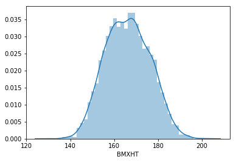

```python
# insert your code here

sns.distplot(da.BMXHT.dropna())
plt.show()
```

**Q3a.** Use the `bins` argument to [distplot](https://seaborn.pydata.org/generated/seaborn.distplot.html) to produce histograms with different numbers of bins. Assess whether the default value for this argument gives a meaningful result, and comment on what happens as the number of bins grows excessively large or excessively small.

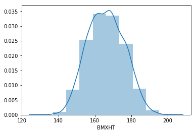

```python
sns.distplot(da.BMXHT.dropna(), bins = 10)
plt.show()
```

**Q3b.** Make separate histograms for the heights of women and men, then make a side-by-side boxplot showing the heights of women and men.

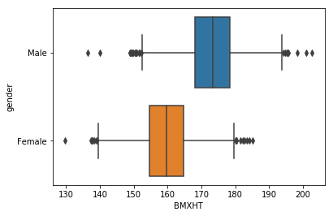

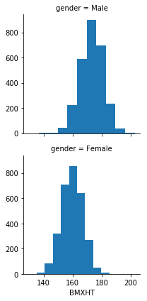

```python
sns.boxplot(x = da_clean.BMXHT, y = da_clean.gender)
hist = sns.FacetGrid(da_clean, row = 'gender')
hist = hist.map(plt.hist, 'BMXHT')

plt.show()
```

**Q3c.** Comment on what features, if any are not represented clearly in the boxplots, and what features, if any, are easier to see in the boxplots than in the histograms.

## Question 4

Make a boxplot showing the distribution of within-subject differences between the first and second systolic blood pressure measurents (BPXSY1 and BPXSY2).

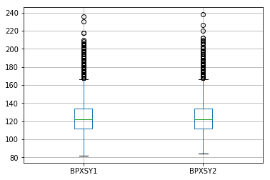

```python
x = da[['BPXSY1', 'BPXSY2']]
x.boxplot()
```